# Jointly Defining Cell Types from scRNA-seq and snATAC-seq Data Using LIGER

Joshua Sodicoff and Joshua Welch

2019-08-21

This vignette shows how to jointly define clusters using single-cell RNA-seq and single-nuclear ATAC-seq data. We will use the peripheral blood mononuclear cell (PBMC) scRNA-seq and snATAC-seq datasets provided by 10X. The workflow for jointly analyzing RNA and ATAC is quite similar to that for integrating multiple RNA datasets. The only differences are (1) we need to process the ATAC data into gene-level values comparable to gene expression and (2) we perform gene selection using the RNA data only.

## Load Pre-Computed Count Matrices for RNA and ATAC Data

Because ATAC-seq measures chromatin accessibility, a different data modality than gene expression, we need to process the ATAC data to obtain gene-level features that we can use to integrate with the RNA data. Although one could imagine many strategies for calculating gene-level features from ATAC data, we found that the simplest possible strategy works well: counting the number of reads that overlap the gene body and promoter for each gene. We show how to do this below starting from the `cellranger` output, but for now we will simply read in the final gene x cell matrices for RNA and ATAC data. These matrices and all other inputs are provided [here] (https://umich.box.com/s/5hkhpou4inrulo570yhc38ay8g3ont5b), so we can load them directly:

```r
rna_clusts = readRDS("rna_cluster_assignments.RDS")
atac_clusts = readRDS("atac_cluster_assignments.RDS")
pbmc.atac <- readRDS('pbmc.atac.expression.mat.RDS')
pbmc.rna <- readRDS('pbmc.rna.expression.mat.RDS')
```

### Calculate Gene-Level Features for ATAC Data

Here we show how to compute a gene x cell feature matrix starting from the `fragments.tsv` file output by the 10X `cellranger count` pipeline. SKip this section for now if you want to simply try out `liger` on the provided counts.

Although one could imagine many strategies for calculating gene-level features from ATAC data, we found that the simplest possible strategy works well: counting the number of reads that overlap the gene body and promoter for each gene. We found that summing the peak counts output by `cellranger count` for the peaks overlapping each gene can also work, but this strategy is less desirable because (1) information from reads not in peaks is lost and (2) the `cellranger` peak calling is performed on all cells, which leads to an overrepresentation of peaks from abundant cell populations and biases against rare cell populations.

We sort the fragments output by `cellranger` by barcode and use the BEDOPS `bedmap` tool to make a list of cell barcodes that overlap each gene and promoter. To perform this step, you need to install BEDOPS (see [this page](https://bedops.readthedocs.io/en/latest/content/installation.html) for installation instructions). The file `atac_fragments.tsv` is available from the 10X website at [this link] (http://cf.10xgenomics.com/samples/cell-atac/1.1.0/atac_v1_pbmc_10k/atac_v1_pbmc_10k_fragments.tsv.gz). Note that this file is very large and the step to sort the file is somewhat slow.

```r
system("sort -k4,4 atac_v1_pbmc_10k_fragments.tsv > atac_fragments.sort.bed")
system("bedmap --delim \"\\t\" --echo --echo-map-id hg19_genes.bed atac_fragments.sort.bed > atac_genes_bc.bed")
system("bedmap --delim \"\\t\" --echo --echo-map-id hg19_promoters.bed atac_fragments.sort.bed > atac_promoters_bc.bed")
```

We then import the bedmap output into R. Note that we use the `as.is` parameter in `read.table` to supress the conversion of character columns like gene symbol to factors. Using Liger’s `makeFeatureMatrix` function, we calculate gene and promoter accessibility counts. Finally, we sort the rows of these matrices by gene symbol and add them together. Note that we could also calculate these combined counts in a single step by combining the gene and promoter BED files; we choose to calculate them separately in case this is useful for downstream analyses.

```r
library(liger)

genes.bc <- read.table(file = "atac_genes_bc.bed", sep = "\t", as.is = c(4,7), header = FALSE)
promoters.bc <- read.table(file = "atac_promoters_bc.bed", sep = "\t", as.is = c(4,7), header = FALSE)

#The makeFeatureMatrix function requires a list of barcodes as a vector
barcodes = names(atac_clusts)
gene.counts <- makeFeatureMatrix(genes.bc, barcodes)
promoter.counts <- makeFeatureMatrix(promoters.bc, barcodes)

gene.counts <- gene.counts[order(rownames(gene.counts)),]
promoter.counts <- promoter.counts[order(rownames(promoter.counts)),]
pbmc.atac <- gene.counts + promoter.counts
```

### Read 10X RNA Output

Liger’s `read10X` function can be used to read `cellranger count` output files into R.

```r
sample.dir = '.'
sample.name = 'pbmc.rna'
pbmc.rna <- read10X(sample.dirs = list(sample.dir), sample.names = list(sample.name))
```

## Data preprocessing

The algorithm takes a list of two or more count matrices as input. Genes should be in rows and cells in columns. We can make a list of the count matrices and pass this as parameter to the `createLiger` function to construct a Liger object.

```r
library(liger)
ggplot2::theme_set(theme_cowplot())
pbmc.data = list(atac=pbmc.atac[,names(atac_clusts)], rna=pbmc.rna[,names(rna_clusts)])
int.pbmc <- createLiger(pbmc.data)
```

Before computing the factorization, we need to normalize the data to account for different capture efficiency and sequencing depth per cell with `normalize`, select variable genes with `selectGenes`, and scale the data with `scaleNotCenter`. Note that we do not mean-center the data because nonnegative matrix factorization requires nonnegative values.

The `selectGenes` function performs variable gene selection on each of the datasets separately, then takes the union of the result. The variable genes are selected by comparing the variance of each gene’s expression to its mean expression. The `selectGenes` function was written primarily scRNA-seq in mind, and snATAC-seq data distribution is quite different. So instead of taking the union of variable genes from RNA and ATAC, we set `datasets.use = 2` in the function to perform gene selection using only the RNA dataset.

```r
int.pbmc <- normalize(int.pbmc)
int.pbmc <- selectGenes(int.pbmc, datasets.use = 2)
int.pbmc <- scaleNotCenter(int.pbmc)
```

### Factorization

Next we perform integrative non-negative matrix factorization in order to identify shared and distinct metagenes across the datasets and the corresponding metagene loadings for each cell. The most important parameters in the factorization are `k` (the number of factors) and `lambda` (the penalty parameter which limits the dataset-specific component of the factorization). The default value of `lambda=5.0` usually provides reasonable results for most analyses. For this analysis, we simply use `k = 20` and the default value of `lambda`.

```r
int.pbmc <- optimizeALS(int.pbmc, k=20)
```

After the factorization, we still need to quantile normalize the factor loadings across the datasets. Notice that if we plot a t-SNE representation of the factor loadings before normalization, the cells still cluster mainly by modality.

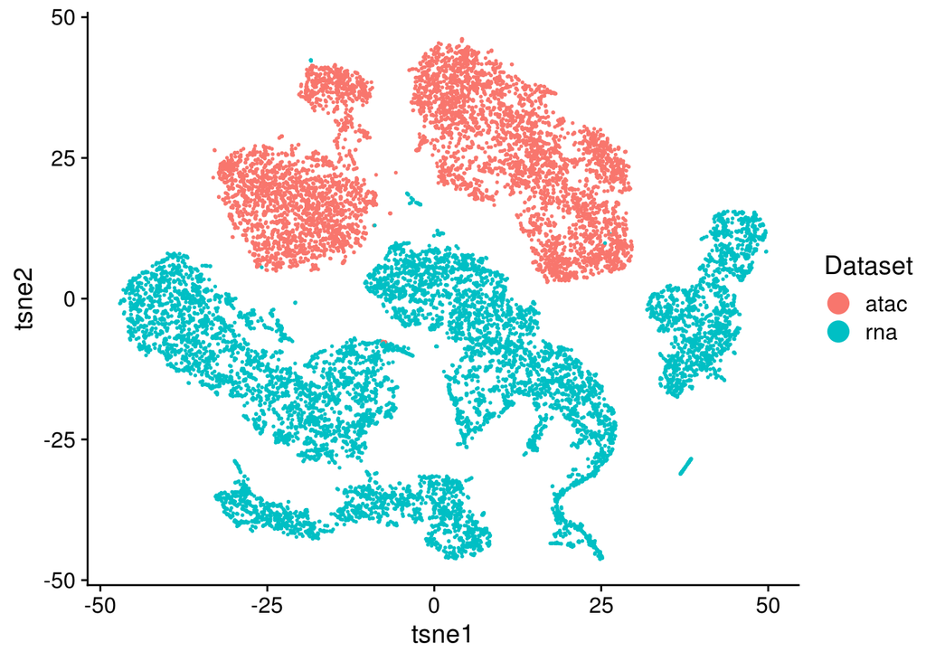

```r
int.pbmc <- runTSNE(int.pbmc, use.raw = T)
p1 <- plotByDatasetAndCluster(int.pbmc, return.plots = T)
print(p1[[1]])
```

To better integrate the datasets, we perform a quantile normalization step. This process first identifies similarly loading cells across datasets by building a similarity graph based on shared factor neighborhoods. Using Louvain community detection, we then jointly identify clusters across datasets, and normalize quantiles within each cluster and factor. The key parameters in this step are `resolution` (increasing this increases the number of communities detected) and `knn_k` (the number of dataset neighbors used in generating the shared factor neighborhood). In general, lowering `knn_k` will allow for more fine-grained identification of smaller groups, but possibly at the cost of decreased alignment across datasets. Here we simply use default settings of `resolution=1.0` and `knn_k=20`.

```r
int.pbmc <- quantileAlignSNF(int.pbmc)
```

### Visualization

Now we can visualize the integrated data.

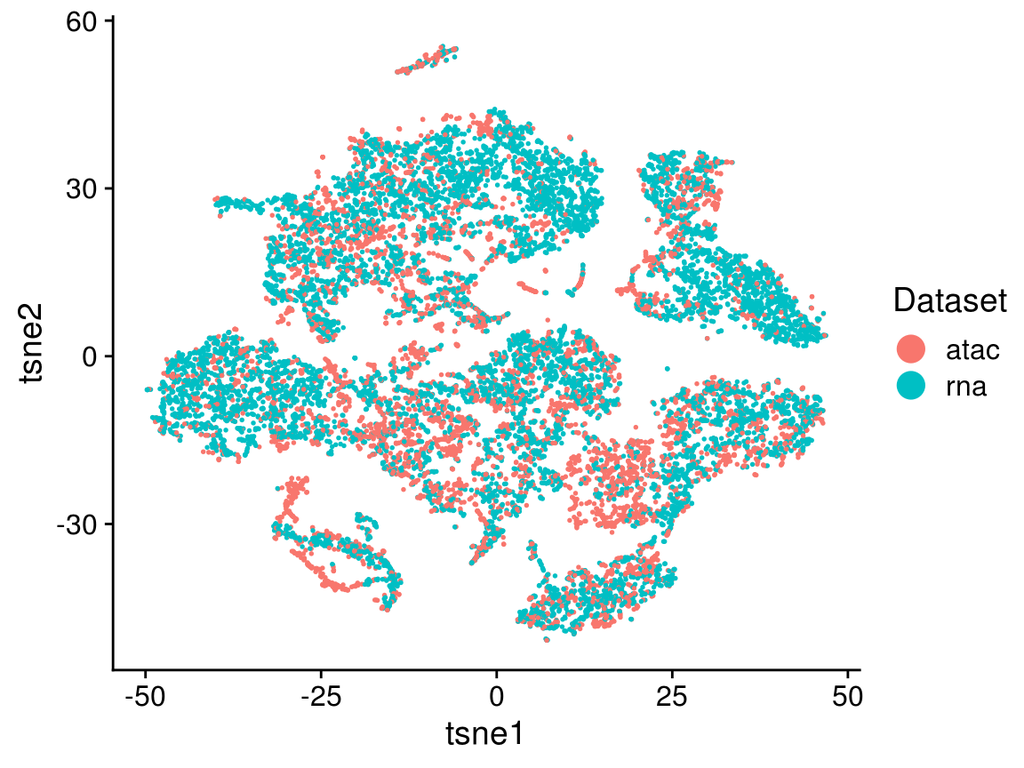

```r
int.pbmc <- runTSNE(int.pbmc)
plots <- plotByDatasetAndCluster(int.pbmc, return.plots = T,clusters=rna_clusts)
print(plots[[1]])
```

To see how the aligned space preserves the structure from the RNA data, we can plot the previously annotated cluster assignments for the RNA profiles:

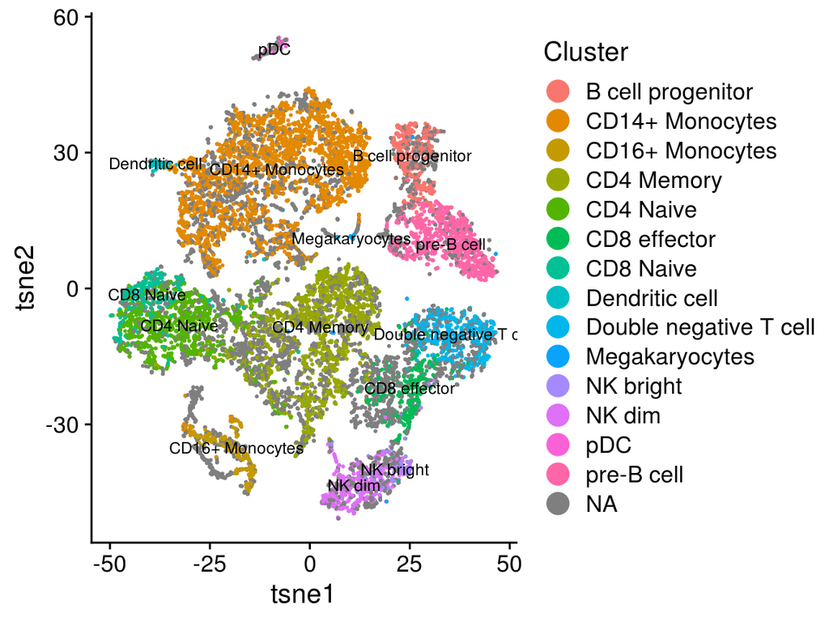

```r
print(plots[[2]])
```

Plotting the expression and accessibility for NK and B-cell markers indicates that these cells are properly aligned.

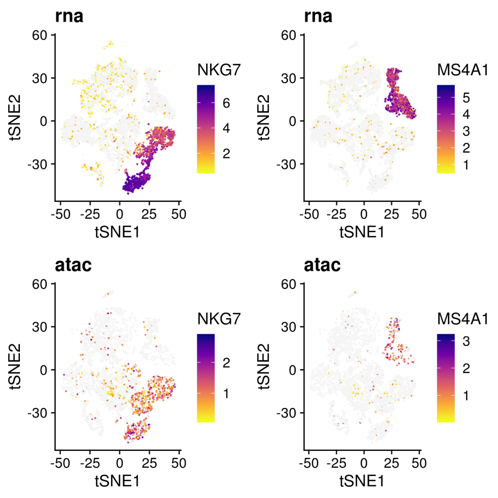

```r
NKG7 = plotGene(int.pbmc,gene="NKG7",return.plots=T)
MS4A1 = plotGene(int.pbmc,gene="MS4A1",return.plots=T)
plot_grid(NKG7[[2]],MS4A1[[2]],NKG7[[1]],MS4A1[[1]],ncol=2)
```